# CapstoneProject_1

```r
#Decided to remove state highway indicator and road conditions because the factors were too one sided to fix:
collision_4=collision_4[,!names(collision_4) %in% c("state_hwy_ind","road_cond_1")]

summary(collision_4)
```

```
##  victim_sex   victim_age       longitude         latitude
##  F:10972    Min.   :  0.00   Min.   :-118.7   Min.   : 0.00
##  M:23012    1st Qu.: 22.00   1st Qu.:-118.4   1st Qu.:34.01
##             Median : 33.00   Median :-118.3   Median :34.05
##             Mean   : 36.95   Mean   :-117.8   Mean   :33.91
##             3rd Qu.: 51.00   3rd Qu.:-118.3   3rd Qu.:34.11
##             Max.   :105.00   Max.   :   0.0   Max.   :34.33
##
##  accident_year  collision_time  day_of_week  primary_rd
##  Min.   :2012   18     : 2780   1:4837      Length:33984
##  1st Qu.:2013   17     : 2746   2:5188      Class :character
##  Median :2015   15     : 2447   3:5364      Mode  :character
##  Mean   :2015   19     : 2367   4:5297
##  3rd Qu.:2017   16     : 2300   5:5349
##  Max.   :2018   07     : 1988   6:4261
##                 (Other):19356   7:3688
##  secondary_rd       intersection weather_1 collision_severity
##  Length:33984       N:16199      A:31052   Min.   :1.000
##  Class :character   Y:17785      B: 2932   1st Qu.:3.000
##  Mode  :character                          Median :3.000
##                                            Mean   :3.292
##                                            3rd Qu.:4.000
##                                            Max.   :4.000
##
##  number_killed     number_injured   pcf_viol_category hit_and_run
##  Min.   :0.00000   Min.   : 0.000   10     :8521      F: 8161
##  1st Qu.:0.00000   1st Qu.: 1.000   11     :6410      N:25823
##  Median :0.00000   Median : 1.000   09     :4245
##  Mean   :0.02584   Mean   : 1.118   05     :3378
##  3rd Qu.:0.00000   3rd Qu.: 1.000   12     :2140
##  Max.   :2.00000   Max.   :14.000   03     :1781
##                                     (Other):7509
##  ped_action road_surface lighting  control_device alcohol_involved
##  A:13730    A:32758      A:22172   A:17702        N:31672
##  B:11078    B: 1226      B: 1342   D:16282        Y: 2312
##  D: 4693                 C: 9979
##  E: 2690                 D:  491
##  F: 1793
##
##
```

```r
str(collision_4)
```

```
## 'data.frame':    33984 obs. of  21 variables:
##  $ victim_sex        : Factor w/ 2 levels "F","M": 1 2 1 2 2 2 2 1 1 2 ...
##  $ victim_age        : num  31 60 66 48 60 58 79 17 79 66 ...
##  $ longitude         : num  -118 -118 -118 -118 -118 ...
##  $ latitude          : num  34.1 34.1 34.2 34.3 34 ...
##  $ accident_year     : int  2012 2012 2012 2012 2012 2012 2012 2012 2012 2012 ...
##  $ collision_time    : Factor w/ 24 levels "00","01","02",..: 15 19 1 18 20 22 19 23 7 17 ...
##  $ day_of_week       : Factor w/ 7 levels "1","2","3","4",..: 3 7 7 2 4 4 2 4 6 3 ...
##  $ primary_rd        : chr  "SALTAIR TERRACE" "AVENUE 26" "FOREST LAWN DRIVE" "SUNLAND BOULEVARD" ...
##  $ secondary_rd      : chr  "SALTAIR AVENUE" "HURON STREET" "MEMORIAL DRIVE - DRIVEWAY" "LA CANADA WAY" ...
##  $ intersection      : Factor w/ 2 levels "N","Y": 1 1 1 1 1 1 1 1 2 1 ...
##  $ weather_1         : Factor w/ 2 levels "A","B": 1 1 2 1 1 1 1 1 2 1 ...
##  $ collision_severity: int  1 1 1 1 1 1 1 1 1 1 ...
##  $ number_killed     : int  1 1 1 1 1 1 1 1 1 1 ...
##  $ number_injured    : int  0 0 0 0 0 0 1 1 0 0 ...
##  $ pcf_viol_category : Factor w/ 15 levels "00","01","03",..: 10 10 10 10 10 10 10 10 9 10 ...
##  $ hit_and_run       : Factor w/ 2 levels "F","N": 2 2 1 2 2 2 2 2 1 2 ...
##  $ ped_action        : Factor w/ 5 levels "A","B","D","E",..: 3 3 3 3 3 3 3 3 2 3 ...
##  $ road_surface      : Factor w/ 2 levels "A","B": 1 1 1 1 1 1 1 1 2 1 ...
##  $ lighting          : Factor w/ 4 levels "A","B","C","D": 1 3 4 3 3 3 1 3 2 1 ...
##  $ control_device    : Factor w/ 2 levels "A","D": 2 2 2 2 2 2 1 2 1 2 ...
##  $ alcohol_involved  : Factor w/ 2 levels "N","Y": 1 1 1 2 2 1 1 1 1 1 ...
```

```r
collision_4=na.omit(collision_4)
```

Look at categorical variables:

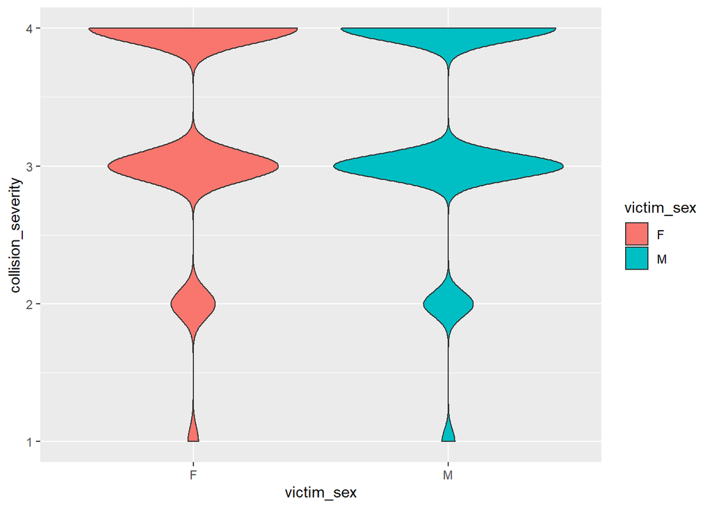

```r
#Gender:
collision_4 %>%
  ggplot(aes(x=victim_sex, y=collision_severity, fill=victim_sex)) + geom_violin()
```

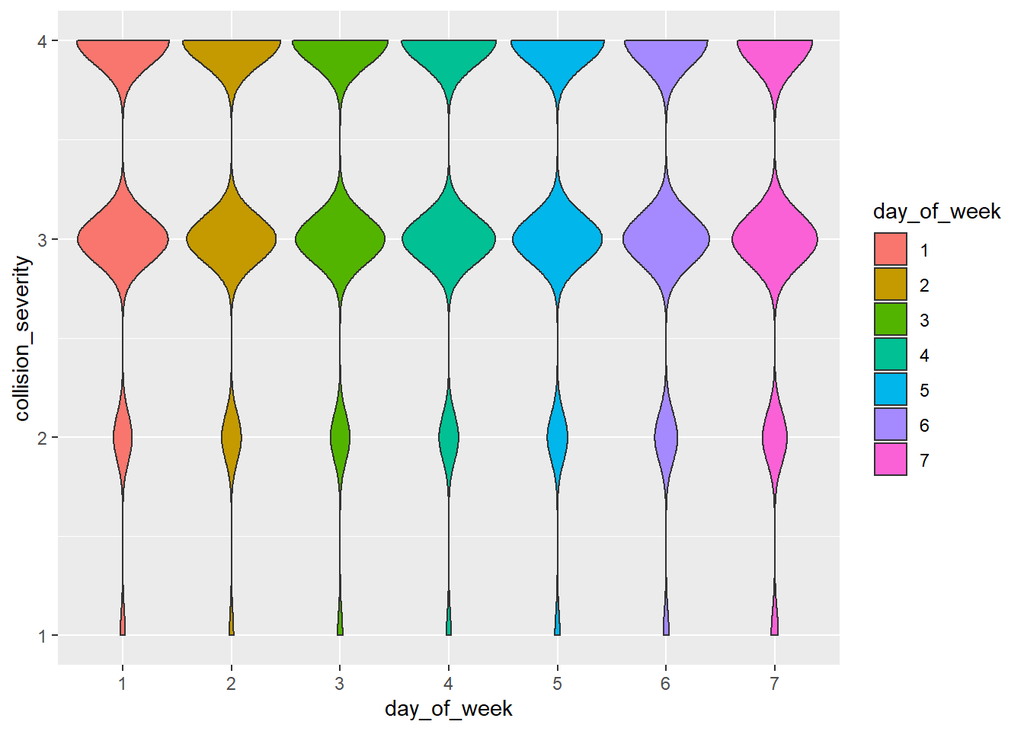

```r
#Day of the week:
collision_4 %>%
  ggplot(aes(x=day_of_week, y=collision_severity,fill=day_of_week)) + geom_violin()
```

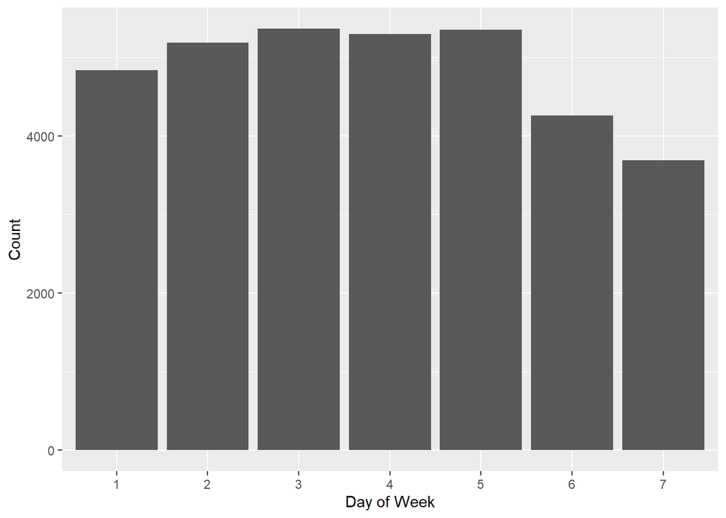

```r
#Saturday and Sunday have a lower number of collisions that week days:
collision_4 %>%
  group_by(day_of_week) %>%
  ggplot(aes(day_of_week)) + geom_bar(aes(y=(..count..)))+
  xlab("Day of Week") + ylab("Count")
```

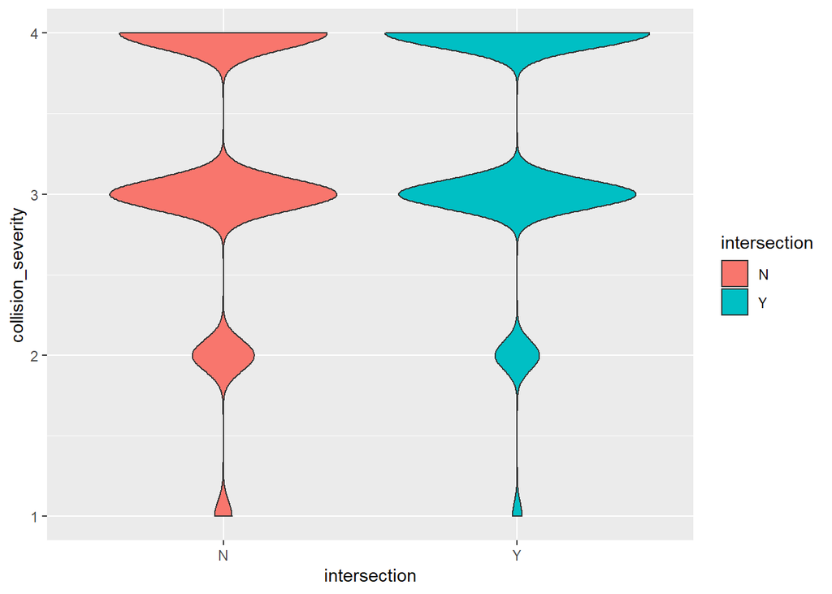

```r
#Intersection;
collision_4 %>%
  ggplot(aes(x=intersection, y=collision_severity,fill=intersection)) + geom_violin()
```

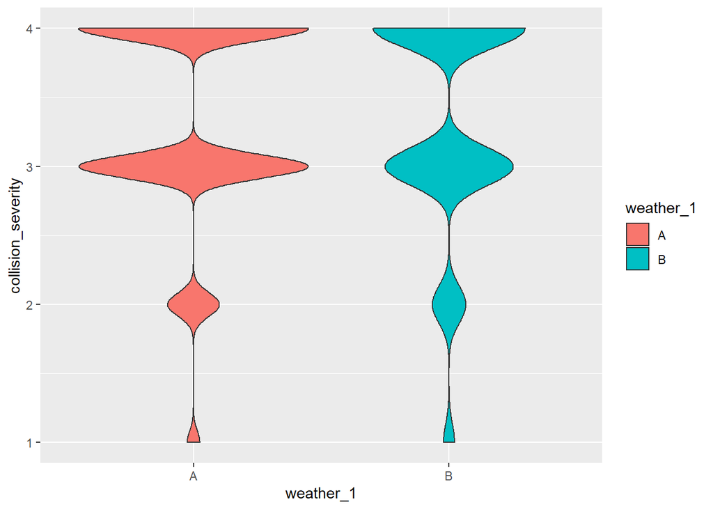

```r
#Weather:
collision_4 %>%
  ggplot(aes(x=weather_1, y=collision_severity,fill=weather_1)) + geom_violin()
```

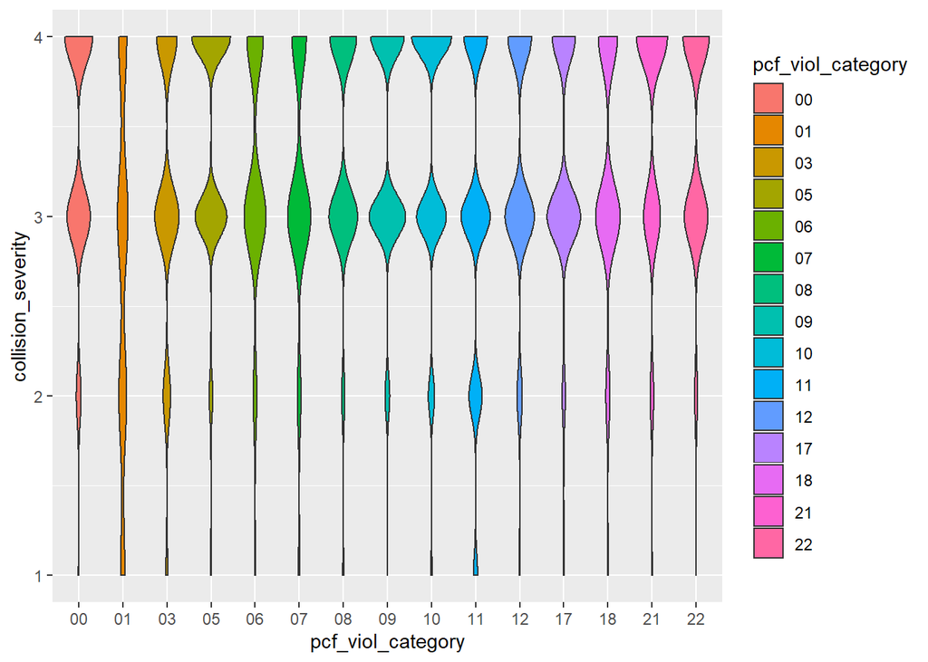

```r
#PCF violation category
collision_4 %>%
  ggplot(aes(x=pcf_viol_category, y=collision_severity,fill=pcf_viol_category)) + geom_violin()
```

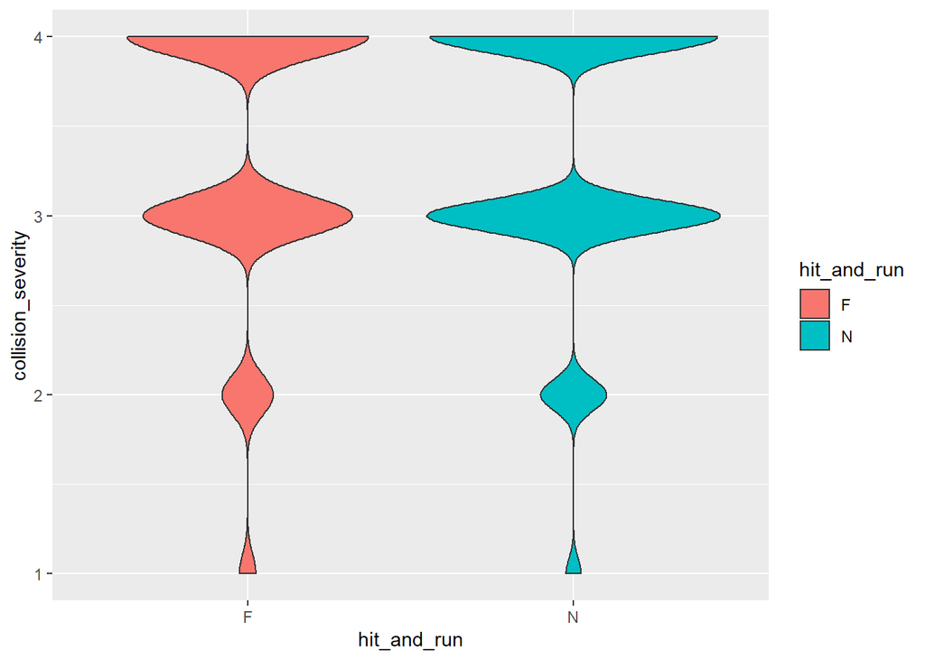

```r
#Hit and run
collision_4 %>%
  ggplot(aes(x=hit_and_run, y=collision_severity,fill=hit_and_run)) + geom_violin()
```

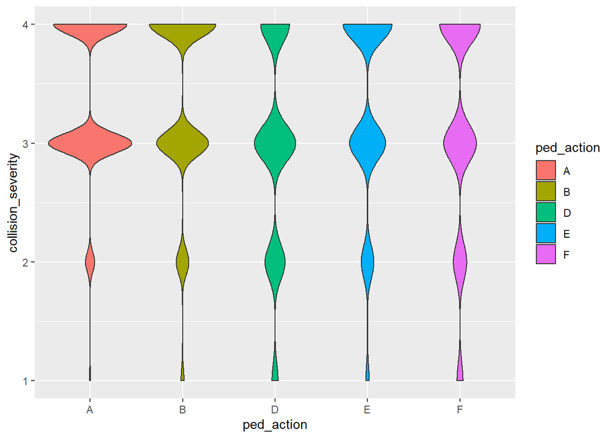

```r
#Ped action
collision_4 %>%
  ggplot(aes(x=ped_action, y=collision_severity,fill=ped_action)) + geom_violin()
```

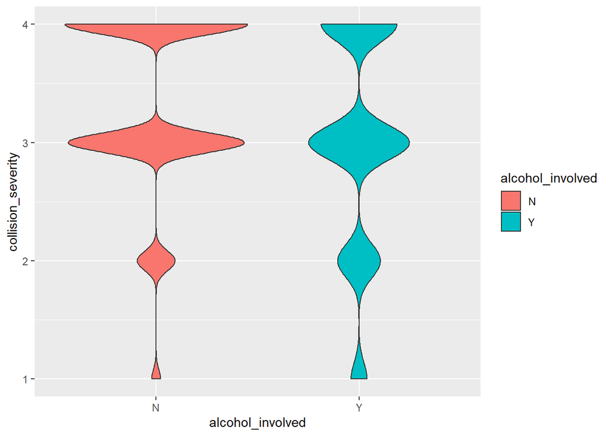

```r
#Alcohol Involved
collision_4 %>%
  ggplot(aes(x=alcohol_involved, y=collision_severity,fill=alcohol_involved)) + geom_violin()
```

Ordered Logistic Regression:

Sunday is signficantly more likely to results in death/high injury. This seems unlikely given that Saturday and Sunday had a lower number of collisions overall, and that by common sense Saturday seems more likely of a day for fatalities given that people tend to drink on Saturdays, and alcohol is also signfiicantly more likely to result in death. However, given that 2-5am is the most dangerous time to be walking/biking, I think it is likely that this time on Sunday is when most deadly crashes happen, after people have been drinking Saturday night.

Walking in an intersection results in less injurious/deadly collisions, which makes sense given they are the safest place for pedestrians to cross.

The Primary collision factors that are most significantly linked to a higher degree of injury/death are speeding, driving/biking under the influence of drugs/alcohol, pedestrian violation, not obeying traffic signs, and unsafe lane change.

One interesting result is that a collision that is not a hit and run is more likely to result in death/serious injury. This is not what I would have expected, but perhaps people are more likely to stop when they think they have severely injured/killed the person because they need more help, and decide to run when they think it is less serious.

The pedestrian actions that are most deadly are crossing not in the crosswalk and when pedestrians are not in the road. One possible reasons pedestrians who are hit while they’re not in the road results in deadlier collisions is that if a car hits you on the sidewalk it indicates very reckless driving, and perhaps they are going faster/the collisions involves multiple cars. Additionally, if you are hit while not in the road it is more likely you will also hit a building/something on the sidewalk which would result in higher injury.

When the road surface is not dry (slick, icy, wet) pedestrians/bikers have a lower degree of injury. This could possibly be because cars have to go slower in those conditions. Additionally, there also just likely less walkers/bikers when the weather is bad.

When it is dark and there are no street lights is the most dangerous place for pedestrians/bikers, but darkness with street lights is still worse than dusk/daylight.

Finally, when alcohol is involved collisions are more deadly as well. This could be because and of the party drinking could result in more reckless behavior.

I also took a look at the relative risk ratio. Since the scale of collision severity goes down, I chose the variables that were least likely to make collision severity move up a prediction class i.e. the lowest percentages. Driving/biking under the influence was the lowest (30% more likely), followed by unsafe lane change (56%), pedestrian violation (57%), unsafe speed (59%), crossing not in the crosswalk (62%), not obeying traffic signs (65%), and improper passing (66%). These results suggest that the most important aspects of determining if a collision will be deadly are the actions of the driver AND the pedestrian. While time of day, lighting, and road surfacing are also all signficant variables, the most important thing to focus on is changing the behaviors of drivers and pedestrians (and bikers too, although there was no specific variables to describe their behavior).

```r
#Remove character variables, location, and number killed/injured which will give the same informtion as collision severity.
collision_5=collision_4[,!names(collision_4) %in% c("primary_rd","secondary_rd","number_killed","number_injured","longitude","latitude")]

str(collision_5)
```

```
## 'data.frame':    33984 obs. of  15 variables:
##  $ victim_sex        : Factor w/ 2 levels "F","M": 1 2 1 2 2 2 2 1 1 2 ...
##  $ victim_age        : num  31 60 66 48 60 58 79 17 79 66 ...
##  $ accident_year     : int  2012 2012 2012 2012 2012 2012 2012 2012 2012 2012 ...
##  $ collision_time    : Factor w/ 24 levels "00","01","02",..: 15 19 1 18 20 22 19 23 7 17 ...
##  $ day_of_week       : Factor w/ 7 levels "1","2","3","4",..: 3 7 7 2 4 4 2 4 6 3 ...
##  $ intersection      : Factor w/ 2 levels "N","Y": 1 1 1 1 1 1 1 1 2 1 ...
##  $ weather_1         : Factor w/ 2 levels "A","B": 1 1 2 1 1 1 1 1 2 1 ...
##  $ collision_severity: int  1 1 1 1 1 1 1 1 1 1 ...
##  $ pcf_viol_category : Factor w/ 15 levels "00","01","03",..: 10 10 10 10 10 10 10 10 9 10 ...
##  $ hit_and_run       : Factor w/ 2 levels "F","N": 2 2 1 2 2 2 2 2 1 2 ...
##  $ ped_action        : Factor w/ 5 levels "A","B","D","E",..: 3 3 3 3 3 3 3 3 2 3 ...
##  $ road_surface      : Factor w/ 2 levels "A","B": 1 1 1 1 1 1 1 1 2 1 ...
##  $ lighting          : Factor w/ 4 levels "A","B","C","D": 1 3 4 3 3 3 1 3 2 1 ...
##  $ control_device    : Factor w/ 2 levels "A","D": 2 2 2 2 2 2 1 2 1 2 ...
##  $ alcohol_involved  : Factor w/ 2 levels "N","Y": 1 1 1 2 2 1 1 1 1 1 ...
```

```r
collision_5$collision_severity=as.factor(collision_5$collision_severity)

#Run Ordered Logistic:
order1 = polr(collision_severity~., data = collision_5, Hess=TRUE)
summary(order1) #AIC=68874
```

```
## Call:
## polr(formula = collision_severity ~ ., data = collision_5, Hess = TRUE)
##
## Coefficients:
##                         Value Std. Error   t value
## victim_sexM         -0.156661  2.371e-02   -6.6074
## victim_age          -0.004927  5.820e-04   -8.4644
## accident_year        0.003988  2.814e-05  141.7044
## collision_time01     0.046768  1.797e-03   26.0203
## collision_time02    -0.261654  1.971e-03 -132.7612
## collision_time03    -0.278864  5.348e-04 -521.4473
## collision_time04    -0.238925  3.206e-04 -745.1695
## collision_time05    -0.369016  6.533e-04 -564.8540
## collision_time06     0.121690  2.112e-03   57.6055
## collision_time07     0.288206  3.943e-02    7.3101
## collision_time08     0.360264  2.678e-02   13.4531
## collision_time09     0.425843  5.070e-03   83.9881
## collision_time10     0.445030  5.011e-03   88.8076
## collision_time11     0.487396  6.144e-03   79.3239
## collision_time12     0.452091  1.056e-02   42.8189
## collision_time13     0.393902  1.354e-02   29.0881
## collision_time14     0.444926  4.057e-02   10.9668
## collision_time15     0.353839  3.714e-02    9.5273
## collision_time16     0.390279  3.812e-02   10.2372
## collision_time17     0.328260  3.542e-02    9.2687
## collision_time18     0.325459  3.539e-02    9.1952
## collision_time19     0.355167  3.696e-02    9.6106
## collision_time20     0.270308  1.225e-02   22.0723
## collision_time21     0.202891  7.795e-03   26.0287
## collision_time22     0.111554  3.821e-03   29.1912
## collision_time23     0.152578  2.660e-03   57.3573
## day_of_week2         0.040972  2.482e-02    1.6508
## day_of_week3         0.013110  2.449e-02    0.5353
## day_of_week4        -0.013998  2.454e-02   -0.5705
## day_of_week5        -0.019871  2.446e-02   -0.8123
## day_of_week6        -0.088367  2.652e-02   -3.3315
## day_of_week7        -0.178341  2.788e-02   -6.3975
## intersectionY        0.144352  2.545e-02    5.6718
## weather_1B          -0.038996  3.137e-02   -1.2430
## pcf_viol_category01 -1.199505  8.839e-03 -135.7098
```

[output cut: 18 more lines]

```
## road_surfaceB        0.384829  1.481e-02   25.9916
## lightingB           -0.059355  1.272e-02   -4.6649
## lightingC           -0.113995  2.103e-02   -5.4214
## lightingD           -0.267097  1.627e-03 -164.1619
## control_deviceD      0.003295  2.545e-02    0.1295
## alcohol_involvedY   -0.189284  4.047e-02   -4.6768
##
## Intercepts:
##     Value     Std. Error t value
## 1|2    3.8950    0.0022  1735.0053
## 2|3    5.6656    0.0315   179.6105
## 3|4    7.9670    0.0331   241.0062
##
## Residual Deviance: 68750.62
## AIC: 68874.62
```

```r
exp(coef(order1))
```

```
##         victim_sexM          victim_age       accident_year
##           0.8549939           0.9950855           1.0039959
##    collision_time01    collision_time02    collision_time03
##           1.0478789           0.7697770           0.7566427
##    collision_time04    collision_time05    collision_time06
##           0.7874737           0.6914140           1.1294034
##    collision_time07    collision_time08    collision_time09
##           1.3340319           1.4337074           1.5308799
##    collision_time10    collision_time11    collision_time12
##           1.5605365           1.6280717           1.5715944
##    collision_time13    collision_time14    collision_time15
##           1.4827553           1.5603750           1.4245262
##    collision_time16    collision_time17    collision_time18
##           1.4773925           1.3885506           1.3846660
##    collision_time19    collision_time20    collision_time21
##           1.4264194           1.3103676           1.2249395
##    collision_time22    collision_time23        day_of_week2
##           1.1180139           1.1648335           1.0418231
##        day_of_week3        day_of_week4        day_of_week5
##           1.0131963           0.9861000           0.9803250
##        day_of_week6        day_of_week7       intersectionY
##           0.9154246           0.8366572           1.1552909
##          weather_1B pcf_viol_category01 pcf_viol_category03
##           0.9617546           0.3013433           0.5932412
## pcf_viol_category05 pcf_viol_category06 pcf_viol_category07
##           1.0969389           0.6691391           0.5690603
## pcf_viol_category08 pcf_viol_category09 pcf_viol_category10
##           0.8796755           0.8431258           1.0100152
## pcf_viol_category11 pcf_viol_category12 pcf_viol_category17
##           0.5759139           0.6565629           0.7568220
## pcf_viol_category18 pcf_viol_category21 pcf_viol_category22
##           0.7221137           1.4931515           1.1146344
##        hit_and_runN         ped_actionB         ped_actionD
##           0.8763659           0.9698784           0.6268366
##         ped_actionE         ped_actionF       road_surfaceB
##           1.2692184           0.7356580           1.4693625
##           lightingB           lightingC           lightingD
##           0.9423723           0.8922623           0.7655987
##     control_deviceD   alcohol_involvedY
##           1.0033002           0.8275516
```

```r
#Run stepwise AIC to see if any variables should be removed
stepAIC(order1, direction="both")
```

```
## Start:  AIC=68874.62
## collision_severity ~ victim_sex + victim_age + accident_year +
##     collision_time + day_of_week + intersection + weather_1 +
##     pcf_viol_category + hit_and_run + ped_action + road_surface +
##     lighting + control_device + alcohol_involved
##
##                     Df   AIC
## - control_device     1 68873
## - accident_year      1 68873
## - weather_1          1 68873
## <none>                 68875
## - lighting           3 68879
## - alcohol_involved   1 68889
## - day_of_week        6 68898
## - hit_and_run        1 68899
## - intersection       1 68903
## - road_surface       1 68903
## - victim_sex         1 68915
## - victim_age         1 68945
## - collision_time    23 68957
## - ped_action         4 69093
## - pcf_viol_category 14 69381
##
## Step:  AIC=68872.64
## collision_severity ~ victim_sex + victim_age + accident_year +
##     collision_time + day_of_week + intersection + weather_1 +
##     pcf_viol_category + hit_and_run + ped_action + road_surface +
##     lighting + alcohol_involved
##
##                     Df   AIC
## - accident_year      1 68871
## - weather_1          1 68871
## <none>                 68873
## + control_device     1 68875
## - lighting           3 68877
## - alcohol_involved   1 68887
## - day_of_week        6 68896
## - hit_and_run        1 68897
## - road_surface       1 68901
## - intersection       1 68904
```

[output cut: 34 more lines]

```
## <none>                 68870
## + weather_1          1 68871
## + accident_year      1 68871
## + control_device     1 68872
## - lighting           3 68874
## - alcohol_involved   1 68884
## - day_of_week        6 68894
## - hit_and_run        1 68895
## - intersection       1 68901
## - road_surface       1 68905
## - victim_sex         1 68911
## - victim_age         1 68940
## - collision_time    23 68952
## - ped_action         4 69090
## - pcf_viol_category 14 69378
```

```
## Call:
## polr(formula = collision_severity ~ victim_sex + victim_age +
##     collision_time + day_of_week + intersection + pcf_viol_category +
##     hit_and_run + ped_action + road_surface + lighting + alcohol_involved,
##     data = collision_5, Hess = TRUE)
##
## Coefficients:
##         victim_sexM          victim_age    collision_time01
##        -0.156629697        -0.004895442         0.046499166
##    collision_time02    collision_time03    collision_time04
##        -0.261849743        -0.279357328        -0.236980656
##    collision_time05    collision_time06    collision_time07
##        -0.369952708         0.119670527         0.285843519
##    collision_time08    collision_time09    collision_time10
##         0.358039591         0.423825488         0.443171428
##    collision_time11    collision_time12    collision_time13
##         0.486013881         0.450715281         0.392562809
##    collision_time14    collision_time15    collision_time16
##         0.443547611         0.352898446         0.389452737
##    collision_time17    collision_time18    collision_time19
##         0.327783618         0.325149174         0.354992349
##    collision_time20    collision_time21    collision_time22
##         0.270839540         0.203719458         0.112320416
##    collision_time23        day_of_week2        day_of_week3
##         0.153759756         0.040693075         0.013075038
##        day_of_week4        day_of_week5        day_of_week6
##        -0.013800973        -0.020057327        -0.088398761
##        day_of_week7       intersectionY pcf_viol_category01
##        -0.178715933         0.141113387        -1.201664688
## pcf_viol_category03 pcf_viol_category05 pcf_viol_category06
##        -0.522177256         0.090352742        -0.404946634
## pcf_viol_category07 pcf_viol_category08 pcf_viol_category09
##        -0.565843967        -0.126370795        -0.170382464
## pcf_viol_category10 pcf_viol_category11 pcf_viol_category12
##         0.010448475        -0.552653610        -0.421263001
## pcf_viol_category17 pcf_viol_category18 pcf_viol_category21
##        -0.279734560        -0.327365882         0.400835115
## pcf_viol_category22        hit_and_runN         ped_actionB
##         0.108419999        -0.132322686        -0.030729067
##         ped_actionD         ped_actionE         ped_actionF
##        -0.466547872         0.240416784        -0.306794576
##       road_surfaceB           lightingB           lightingC
##         0.352549147        -0.060900876        -0.114580992
##           lightingD   alcohol_involvedY
##        -0.267419114        -0.188838704
##
## Intercepts:
##         1|2         2|3         3|4
## -4.14184993 -2.37113321 -0.06982385
##
## Residual Deviance: 68751.95
## AIC: 68869.95
```

```r
#Remove accident year, weather, and control device:
order2=polr(collision_severity ~ victim_sex + victim_age +
    collision_time + day_of_week + intersection + pcf_viol_category +
    hit_and_run + ped_action + road_surface + lighting + alcohol_involved,
    data = collision_5, Hess = TRUE)
summary(order2) #AIC 68869
```

```
## Call:
## polr(formula = collision_severity ~ victim_sex + victim_age +
##     collision_time + day_of_week + intersection + pcf_viol_category +
##     hit_and_run + ped_action + road_surface + lighting + alcohol_involved,
##     data = collision_5, Hess = TRUE)
##
## Coefficients:
##                         Value Std. Error  t value
## victim_sexM         -0.156630   0.023962  -6.5365
## victim_age          -0.004895   0.000578  -8.4702
## collision_time01     0.046499   0.130560   0.3562
## collision_time02    -0.261850   0.133243  -1.9652
## collision_time03    -0.279357   0.173350  -1.6115
## collision_time04    -0.236981   0.181075  -1.3087
## collision_time05    -0.369953   0.139202  -2.6577
## collision_time06     0.119671   0.118751   1.0077
## collision_time07     0.285844   0.108604   2.6320
## collision_time08     0.358040   0.109923   3.2572
## collision_time09     0.423825   0.111894   3.7877
## collision_time10     0.443171   0.111922   3.9596
## collision_time11     0.486014   0.111268   4.3680
## collision_time12     0.450715   0.110315   4.0857
## collision_time13     0.392563   0.109956   3.5702
## collision_time14     0.443548   0.108358   4.0934
## collision_time15     0.352898   0.106522   3.3129
## collision_time16     0.389453   0.106602   3.6533
## collision_time17     0.327784   0.101179   3.2396
## collision_time18     0.325149   0.098884   3.2882
## collision_time19     0.354992   0.098003   3.6223
## collision_time20     0.270840   0.098902   2.7385
## collision_time21     0.203719   0.101146   2.0141
## collision_time22     0.112320   0.105147   1.0682
## collision_time23     0.153760   0.111947   1.3735
## day_of_week2         0.040693   0.038523   1.0563
## day_of_week3         0.013075   0.038198   0.3423
## day_of_week4        -0.013801   0.038235  -0.3609
## day_of_week5        -0.020057   0.038182  -0.5253
## day_of_week6        -0.088399   0.040621  -2.1762
## day_of_week7        -0.178716   0.042324  -4.2226
## intersectionY        0.141113   0.024704   5.7121
```

[output cut: 18 more lines]

```
## ped_actionF         -0.306795   0.054247  -5.6555
## road_surfaceB        0.352549   0.058648   6.0112
## lightingB           -0.060901   0.060129  -1.0128
## lightingC           -0.114581   0.045772  -2.5033
## lightingD           -0.267419   0.096390  -2.7743
## alcohol_involvedY   -0.188839   0.047225  -3.9987
##
## Intercepts:
##     Value    Std. Error t value
## 1|2  -4.1418   0.1252   -33.0815
## 2|3  -2.3711   0.1212   -19.5577
## 3|4  -0.0698   0.1204    -0.5801
##
## Residual Deviance: 68751.95
## AIC: 68869.95
```

```r
exp(coef(order2))
```

```
##         victim_sexM          victim_age    collision_time01
##           0.8550206           0.9951165           1.0475972
##    collision_time02    collision_time03    collision_time04
##           0.7696267           0.7562696           0.7890066
##    collision_time05    collision_time06    collision_time07
##           0.6907670           1.1271254           1.3308842
##    collision_time08    collision_time09    collision_time10
##           1.4305223           1.5277950           1.5576393
##    collision_time11    collision_time12    collision_time13
##           1.6258226           1.5694344           1.4807709
##    collision_time14    collision_time15    collision_time16
##           1.5582254           1.4231866           1.4761727
##    collision_time17    collision_time18    collision_time19
##           1.3878886           1.3842371           1.4261697
##    collision_time20    collision_time21    collision_time22
##           1.3110647           1.2259542           1.1188713
##    collision_time23        day_of_week2        day_of_week3
##           1.1662107           1.0415324           1.0131609
##        day_of_week4        day_of_week5        day_of_week6
##           0.9862938           0.9801425           0.9153958
##        day_of_week7       intersectionY pcf_viol_category01
##           0.8363434           1.1515552           0.3006932
## pcf_viol_category03 pcf_viol_category05 pcf_viol_category06
##           0.5932275           1.0945603           0.6670124
## pcf_viol_category07 pcf_viol_category08 pcf_viol_category09
##           0.5678807           0.8812880           0.8433422
## pcf_viol_category10 pcf_viol_category11 pcf_viol_category12
##           1.0105033           0.5754208           0.6562175
## pcf_viol_category17 pcf_viol_category18 pcf_viol_category21
##           0.7559844           0.7208200           1.4930711
## pcf_viol_category22        hit_and_runN         ped_actionB
##           1.1145157           0.8760583           0.9697383
##         ped_actionD         ped_actionE         ped_actionF
##           0.6271636           1.2717791           0.7358017
##       road_surfaceB           lightingB           lightingC
##           1.4226896           0.9409165           0.8917397
##           lightingD   alcohol_involvedY
##           0.7653522           0.8279200
```

```r
#Group age into factor - divided based on the age distribution of collisions:
collision_5$victim_age=ifelse(collision_5$victim_age<12,"1",ifelse(collision_5$victim_age<37,"2",ifelse(collision_5$victim_age<63,"3","4")))
collision_5$victim_age=as.factor(collision_5$victim_age)
str(collision_5)
```

```
## 'data.frame':    33984 obs. of  15 variables:
##  $ victim_sex        : Factor w/ 2 levels "F","M": 1 2 1 2 2 2 2 1 1 2 ...
##  $ victim_age        : Factor w/ 4 levels "1","2","3","4": 2 3 4 3 3 3 4 2 4 4 ...
##  $ accident_year     : int  2012 2012 2012 2012 2012 2012 2012 2012 2012 2012 ...
##  $ collision_time    : Factor w/ 24 levels "00","01","02",..: 15 19 1 18 20 22 19 23 7 17 ...
##  $ day_of_week       : Factor w/ 7 levels "1","2","3","4",..: 3 7 7 2 4 4 2 4 6 3 ...
##  $ intersection      : Factor w/ 2 levels "N","Y": 1 1 1 1 1 1 1 1 2 1 ...
##  $ weather_1         : Factor w/ 2 levels "A","B": 1 1 2 1 1 1 1 1 2 1 ...
##  $ collision_severity: Factor w/ 4 levels "1","2","3","4": 1 1 1 1 1 1 1 1 1 1 ...
##  $ pcf_viol_category : Factor w/ 15 levels "00","01","03",..: 10 10 10 10 10 10 10 10 9 10 ...
##  $ hit_and_run       : Factor w/ 2 levels "F","N": 2 2 1 2 2 2 2 2 1 2 ...
##  $ ped_action        : Factor w/ 5 levels "A","B","D","E",..: 3 3 3 3 3 3 3 3 2 3 ...
##  $ road_surface      : Factor w/ 2 levels "A","B": 1 1 1 1 1 1 1 1 2 1 ...
##  $ lighting          : Factor w/ 4 levels "A","B","C","D": 1 3 4 3 3 3 1 3 2 1 ...
##  $ control_device    : Factor w/ 2 levels "A","D": 2 2 2 2 2 2 1 2 1 2 ...
##  $ alcohol_involved  : Factor w/ 2 levels "N","Y": 1 1 1 2 2 1 1 1 1 1 ...
```

```r
#The regression with age grouped as a factor has the lowest AIC
order3=polr(collision_severity ~ victim_sex + victim_age +
    collision_time + day_of_week + intersection + pcf_viol_category +
    hit_and_run + ped_action + road_surface + lighting + alcohol_involved,
    data = collision_5, Hess = TRUE)
summary(order3) #AIC 68674
```

```
## Call:
## polr(formula = collision_severity ~ victim_sex + victim_age +
##     collision_time + day_of_week + intersection + pcf_viol_category +
##     hit_and_run + ped_action + road_surface + lighting + alcohol_involved,
##     data = collision_5, Hess = TRUE)
##
## Coefficients:
##                        Value Std. Error  t value
## victim_sexM         -0.15341    0.02400  -6.3917
## victim_age2          0.44411    0.05037   8.8178
## victim_age3          0.38437    0.05128   7.4953
## victim_age4         -0.10879    0.05808  -1.8731
## collision_time01     0.03585    0.13084   0.2740
## collision_time02    -0.26664    0.13346  -1.9978
## collision_time03    -0.28043    0.17361  -1.6153
## collision_time04    -0.23116    0.18163  -1.2727
## collision_time05    -0.35940    0.13911  -2.5836
## collision_time06     0.11966    0.11886   1.0068
## collision_time07     0.32756    0.10881   3.0103
## collision_time08     0.37928    0.11008   3.4454
## collision_time09     0.43897    0.11204   3.9179
## collision_time10     0.45828    0.11206   4.0895
## collision_time11     0.49795    0.11141   4.4695
## collision_time12     0.45999    0.11047   4.1641
## collision_time13     0.41456    0.11011   3.7650
## collision_time14     0.47269    0.10853   4.3554
## collision_time15     0.38759    0.10670   3.6325
## collision_time16     0.41793    0.10676   3.9147
## collision_time17     0.35973    0.10135   3.5495
## collision_time18     0.36285    0.09907   3.6624
## collision_time19     0.39251    0.09819   3.9975
## collision_time20     0.29454    0.09907   2.9732
## collision_time21     0.21142    0.10129   2.0873
## collision_time22     0.11431    0.10529   1.0857
## collision_time23     0.15687    0.11214   1.3989
## day_of_week2         0.03898    0.03858   1.0102
## day_of_week3         0.01197    0.03825   0.3130
## day_of_week4        -0.01189    0.03829  -0.3105
## day_of_week5        -0.02022    0.03824  -0.5288
## day_of_week6        -0.08291    0.04070  -2.0371
```

[output cut: 20 more lines]

```
## ped_actionF         -0.25410    0.05445  -4.6664
## road_surfaceB        0.34903    0.05875   5.9412
## lightingB           -0.06856    0.06023  -1.1383
## lightingC           -0.13904    0.04586  -3.0321
## lightingD           -0.28496    0.09652  -2.9522
## alcohol_involvedY   -0.23214    0.04738  -4.8991
##
## Intercepts:
##     Value    Std. Error t value
## 1|2  -3.5690   0.1335   -26.7319
## 2|3  -1.7965   0.1299   -13.8333
## 3|4   0.5145   0.1294     3.9764
##
## Residual Deviance: 68552.42
## AIC: 68674.42
```

Conclusions: Vision Zero should continue to focus on trying to get cars to slow down, as speed is an important factor in determining pedestrian/biker deaths. They should also work on installing more lights since the darkest times are the most deadly, and dark with no lights is the most dangerous lighting state. However, even with lights, darkness is still more dangerous than daytime/dusk.

Although there is not much to be done about nightime being more dangerous as it will always be harder to see pedestrians/bikers at night, perhaps having more police/emergergency workers available at night could at least mean that collisions will be responded to more quickly. Specifically Saturday night/early Sunday morning should have a lot of coverage.

The results indicate that while the driver action is obviouosly important, pedestrian actions are important too. Not crossing in the crosswalk and pedestrian violation were both significantly more likely to result in death/serious injury. One possible solution is increasing the number of crosswalks, especially in areas where there is a long distance between intersections, so that pedestrians are less likely to cross dangerously. Another option is trying to decrease jay walking, perhaps by given out more jaywalking tickets so pedestrians are less likely to cross without a cross walk.

Alcohol is also an extremely important predictor of whether an accident will be deadly. Vision Zero should also focus efforts on reducing drunk driving, perhaps by increasing DUI checkpoints.